# Renten

Fundamentet for al prisfastsættelse

Niklas Lehmann Jensen

## Introduktion

#### Dagens spørgsmål

- Hvad er renten prisen på?
- Hvad er forskellen på nominel rente og realrente?
- Hvorfor er “en rente på 4%” en ufuldstændig oplysning?
- Hvilke renter forankrer det korte danske pengemarked?

#### Læringsmål

Efter kapitlet kan I:

- forklare renten som prisen på at flytte købekraft over tid
- bruge Fisher-relationen og simpel diskontering
- forklare, hvorfor rente og løbetid hører sammen
- beskrive Nationalbankens rolle under fastkurspolitikken
- skelne mellem **referencerente, fixing, kurve og rentetillæg**
- skelne mellem pålydende og effektiv rente

## Renten er en pris

#### Renten flytter købekraft mellem tidspunkter

- Opsparing: udskyd forbrug og modtag kompensation
- Lån: få købekraft nu og betal for tidsforskydningen
- Renten er derfor ikke kun “prisen på et lån”

$$5.000\cdot1{,}02=5.100\text{ kr.}$$

De 100 kr. er kompensationen for ét år uden cyklen.

#### Markedet finder en ligevægtsrente

- Udbud: husholdninger og virksomheder med opsparing
- Efterspørgsel: boligkøbere, virksomheder og staten
- Over $r^*$: overskud af opsparing presser renten ned
- Under $r^*$: låntagere byder renten op

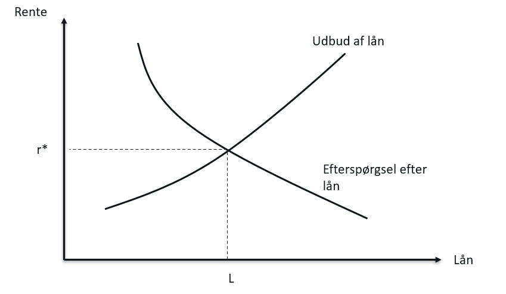

## Nominel rente, realrente og inflation

#### Nominel vækst er ikke det samme som købekraft

**Definition**

**Nominel rente:** vækst i kroner og øre.

**Realrente:** vækst i købekraft.

Broen mellem dem er den forventede inflation. Vokser saldoen langsommere end priserne, bliver investor fattigere målt i købekraft.

#### Fisher-relationen forbinder de tre størrelser

$$(1+R)=(1+r)(1+\pi)
\quad\Longleftrightarrow\quad
r=\frac{R-\pi}{1+\pi}$$

Ved moderate niveauer:

$$R\approx r+\pi$$

**Indsigt**

$R=0{,}3\%$ og $\pi=3{,}0\%$ giver cirka **−2,7% realrente**.

## Renten oversætter fremtid til nutid

#### Diskontering gør betalinger sammenlignelige

$$PV=\frac{A}{(1+r)^t}$$

Ved 10% rente:

$$PV(110\text{ kr. om ét år})=\frac{110}{1{,}10}=100\text{ kr.}$$

**Indsigt**

Jo højere rente og jo længere ventetid, desto lavere nutidsværdi.

#### Renten kan ændre selve investeringsbeslutningen

Et projekt koster 10 mio. kr. og betaler 3 mio. kr. årligt i fire år.

Ved 5%:

$$NPV_{5\%}=+0{,}64\text{ mio. kr.}$$

**Projektet skaber værdi.**

Ved 9%:

$$NPV_{9\%}=-0{,}28\text{ mio. kr.}$$

**Projektet destruerer værdi.**

#### Rente op betyder lavere aktivpriser

**Indsigt**

$$\text{Rente}\uparrow
\Rightarrow
\text{nutidsværdi af fremtidige betalinger}\downarrow
\Rightarrow
\text{aktivpris}\downarrow$$

Det gælder obligationer, aktier og investeringsprojekter.

## Rente og løbetid

#### “4%” er ufuldstændigt uden en løbetid

**Definition**

**Rentekurven** viser sammenhængen mellem renteniveau og løbetid.

- 4% i seks måneder er ikke 4% i 30 år
- En 30-årig statsobligation har typisk højere rente end en 2-årig
- Kurven kan være stigende, flad eller invers
- Hver rente skal angives med både sats og løbetid

## Den korte danske rente

#### Fastkurspolitikken forankrer den korte ende

- Folio- og udlånsrenten påvirker dag-til-dag-likviditet
- Fastkurspolitik siden **1982** binder kronen til euroen
- Danske korte renter følger derfor ECB tæt
- Negative danske renter prægede store dele af **2012–2022**
- Målet er kronekursen — ikke den danske konjunktur

#### Pengepolitikken styrer ikke hele kurven

**Indsigt**

**Kort sigt:** Nationalbanken kan flytte korte nominelle renter hurtigt.

**Langt sigt:** opsparing, investeringer og inflationsforventninger former lange renter og realrenten.

Nationalbanken forankrer den korte ende; resten af kurven dannes i markedet.

## Referencerenter

#### Betalt rente består af reference plus tillæg

$$\text{Betalt rente}_t=\text{referencerente}_t+\text{rentetillæg}$$

**Definition**

**Referencerenten** er kontraktens markedsindeks. En **fixing** er det offentliggjorte tal på en bestemt dag. **Rentetillægget** er den ekstra rente, der følger kontrakten.

**Important**

Et kontraktfastsat tillæg er ikke det samme som et målt spænd til en referencekurve.

#### DESTR og CIBOR beskriver forskellige perioder

| Reference | Hvad beskriver den? | Datagrundlag / risiko |
| --- | --- | --- |
| **DESTR** | Usikret dag-til-dag-likviditet i kroner | Faktiske transaktioner; helt kort byggesten |
| **CIBOR 3M** | Usikret finansiering i tre måneder | Panelbankvurdering; løbetids-, kredit- og likviditetspræmie |
| **CIBOR 6M** | Usikret finansiering i seks måneder | Længere renteperiode; kan ligge på et andet niveau |

**CITA** er et dansk benchmark for korte renteswaps og behandles ikke som en fjerde hovedreference her.

#### En fixing er et punkt; observationer danner en kort kurve

[figure not shown]

#### Kurvepunkt og fixing er to forskellige tidsbegreber

| Horisont fra 9. juni 2026 | DESTR-baseret | CIBOR 3M | CIBOR 6M |
| --- | --- | --- | --- |
| Ca. 3 måneder | 1,89% | 2,34% | 2,51% |
| Ca. 6 måneder | 2,03% | 2,50% | 2,68% |
| Ca. 9 måneder | 2,13% | 2,61% | 2,81% |
| 1 år | 2,21% | 2,69% | 2,89% |

**Indsigt**

“3M” i CIBOR 3M er renteperioden; tabellens rækker er horisonten fra værdiansættelsesdatoen.

#### Kuponreference og diskonteringskurve har forskellige job

- **Kuponvilkåret** bestemmer fremtidige betalinger
- **Fixingen** fastsætter den variable kupon for en renteperiode
- **Referencekurven** samler konstruerede renter på tværs af løbetider
- **Diskonteringskurven** oversætter de fremtidige betalinger til værdi i dag

**Important**

Objekterne kan være beslægtede, men de er ikke det samme.

## Pålydende og effektiv rente

#### Den pålydende rente er ikke nødvendigvis afkastet

**Definition**

**Pålydende rente:** satsen i vilkårene—på en obligation er det kuponrenten.

**Effektiv rente:** den samlede årlige forrentning, når rente på rente, købskurs og betalingstidspunkter regnes med.

En 5% kupon betaler 5 kr. årligt pr. 100 kr. hovedstol, men investors afkast afhænger også af kursen.

#### Tilskrivningsfrekvens ændrer den effektive rente

$$r_{eff}=\left(1+\frac{r}{m}\right)^m-1$$

6% p.a. med halvårlig tilskrivning:

$$\left(1+\frac{0{,}06}{2}\right)^2-1=6{,}09\%$$

**Indsigt**

Sammenlign kun renter direkte, når periode og tilskrivningsfrekvens er ens.

## Afrunding

#### Tre renter I møder igen

| Rente | Rolle | Hvor kommer den igen? |
| --- | --- | --- |
| Kuponrente | Aftalt betaling til investor | Kapitel 2 |
| Referencerente + tillæg | Variabel kupon på lån og obligationer | Kapitel 5 |
| Diskonteringsrente / rentekurve | Oversætter betalingsrækker til pris og risiko | Kapitel 2, 3 og 7 |

#### The Takeaways

1. Renten er prisen på at flytte købekraft over tid og fundamentet for diskontering.
2. Nominel rente er omtrent realrente plus forventet inflation.
3. En rente skal altid angives med sin løbetid.
4. Nationalbanken forankrer den korte ende under fastkurspolitikken.
5. En fixing er ét punkt; referencekurver samler renter for mange løbetider.

#### Øvelse: tre rentebriller

1. Fisher: $R=5\%$ og $\pi=3\%$. Find den omtrentlige og præcise realrente.
2. Diskontering: find $PV$ af 1.000 kr. om tre år ved 4%.
3. Frekvens: omregn 8% p.a. med månedlig tilskrivning til effektiv årlig rente.
4. Begreber: forklar forskellen på en CIBOR 3M-fixing og et etårigt punkt på CIBOR 3M-kurven.